# Oogonia per meter

Chelsey Wegener

9/11/2020

Goal: to calculate and visualize (not sure which graph type is best) oogonia per meter. This is calculated: (average oogonia/#conceptacles) * (#conceptacles/receptacles)=average oogonia/receptacle –> (average oogonia/receptacle) * (1receptacle/2 reproductive apice)= oogonia/reproductive apice –> (oogonia/reproductive apice) * (reproductive apice/ large thallus density)=oogonia per large thallus –>take the average of (oogonia/large thallus) (3 values to 1 value per month) –> average(oogonia/large thallus) * (large thallus/0.25m<sup>2)=oogonia/m</sup>2 –>take average to get average oogonia per meter

Read in and format data

```r
alldata<-read.csv("C:/Users/chels/Box Sync/Thesis/Data/Working data/Riggins_Wegener_field_data_Sept2020.csv", header = TRUE, sep=",", fileEncoding="UTF-8-BOM", stringsAsFactors = FALSE)

alldata$Date<-as.Date(alldata$Date, format = c("%m/%d/%Y"))

library(ggplot2)
library(ggpubr)
library(scales)
library(lubridate)
library(readr)
library(dplyr)
library(chron)
library(plotly)
library(dplyr)
```

Calculate

```r
alldata$avgoo <- rowMeans(alldata[,c('one', 'two', 'three')], na.rm=TRUE)
alldata$conperrec<-alldata$avgoo*alldata$Concept
alldata$ooperra<-alldata$conperrec/2
alldata$ooperthallus<-alldata$ooperra*alldata$RA
```

Now I have oogonia per thallus. I need to take the average of these values per month persite before I continue I’m going to subset by site

```r
HSooperm<-subset(alldata, alldata$Site == "HS")
BYooperm<-subset(alldata, alldata$Site == "BY")
NDooperm<-subset(alldata, alldata$Site == "ND")
PCooperm<-subset(alldata, alldata$Site == "PC")
```

Calculate the average oogonia per thallus by month

```r
HSoopermdf<-aggregate(ooperthallus ~ Date, HSooperm, mean)
BYoopermdf<-aggregate(ooperthallus ~ Date, BYooperm, mean)
NDoopermdf<-aggregate(ooperthallus ~ Date, NDooperm, mean)
PCoopermdf<-aggregate(ooperthallus ~ Date, PCooperm, mean)
```

I need to insert these values back into my df to continue calulating.

```r
print(HSoopermdf)
```

```
##          Date ooperthallus
## 1  2018-06-15    456428.67
## 2  2018-07-16    328095.67
## 3  2018-08-06     99402.33
## 4  2018-09-10    443447.11
## 5  2018-10-09    130327.44
## 6  2018-11-06   1135680.89
## 7  2018-12-04     14653.00
## 8  2019-01-31    100305.22
## 9  2019-02-21     29931.78
## 10 2019-03-14    188142.22
## 11 2019-04-09    687422.00
## 12 2019-05-08   2036749.33
## 13 2019-06-08    655863.56
## 14 2019-07-20    270178.11
## 15 2019-08-04    333053.33
```

```r
print(BYoopermdf)
```

```
##          Date ooperthallus
## 1  2018-06-15    62798.778
## 2  2018-07-16    13859.556
## 3  2018-08-06    26579.111
## 4  2018-09-10    23930.222
## 5  2018-10-09   386300.889
## 6  2018-11-06   382297.778
## 7  2018-12-04   289149.111
## 8  2019-01-31    60958.444
## 9  2019-02-21    82913.333
## 10 2019-03-14   100561.889
## 11 2019-04-09    48415.000
## 12 2019-05-08     8695.333
## 13 2019-06-08   219347.333
## 14 2019-07-20     1346.667
## 15 2019-08-04    36434.000
```

```r
print(NDoopermdf)
```

```
##          Date ooperthallus
## 1  2018-06-14    224814.67
## 2  2018-07-17    261720.67
## 3  2018-08-07     40890.00
## 4  2018-09-11     11622.89
## 5  2018-10-10   1077686.67
## 6  2018-12-05    342350.33
## 7  2019-01-30     90319.56
## 8  2019-02-20     33894.11
## 9  2019-03-15     59873.78
## 10 2019-04-11    109256.00
## 11 2019-05-09     61150.00
## 12 2019-06-09     90213.33
## 13 2019-07-21     30833.00
## 14 2019-08-04     73592.89
```

```r
print(PCoopermdf)
```

```
##          Date ooperthallus
## 1  2018-06-14   557075.889
## 2  2018-07-17    67533.222
## 3  2018-08-07     1726.667
## 4  2018-09-11    12830.000
## 5  2018-12-05   278007.889
## 6  2019-01-30   159910.667
## 7  2019-02-20   146512.778
## 8  2019-03-15    29954.667
## 9  2019-04-11    26138.000
## 10 2019-05-09        0.000
## 11 2019-06-09    21804.667
## 12 2019-07-21    17371.778
## 13 2019-08-04        0.000
```

This sets a value (calculted in the HSoopermdf) to the corresponding date

```r
HSooperm$avooperthallus[HSooperm$Date == "2018-06-15"]<-    "456428.67"
HSooperm$avooperthallus[HSooperm$Date == "2018-07-16"]<-    "328095.67"
HSooperm$avooperthallus[HSooperm$Date == "2018-08-06"]<-    "99402.33"
HSooperm$avooperthallus[HSooperm$Date == "2018-09-10"]<-    "443447.11"
HSooperm$avooperthallus[HSooperm$Date == "2018-10-09"]<-    "130327.44"
HSooperm$avooperthallus[HSooperm$Date == "2018-11-06"]<-    "1135680.89"
HSooperm$avooperthallus[HSooperm$Date == "2018-12-04"]<-    "14653.00"
HSooperm$avooperthallus[HSooperm$Date == "2019-01-31"]<-    "100305.22"
HSooperm$avooperthallus[HSooperm$Date == "2019-02-21"]<-    "29931.78"
HSooperm$avooperthallus[HSooperm$Date == "2019-03-14"]<-    "188142.22"

BYooperm$avooperthallus[BYooperm$Date == "2018-06-15"]<-    "62798.778"
BYooperm$avooperthallus[BYooperm$Date == "2018-07-16"]<-    "13859.556"
BYooperm$avooperthallus[BYooperm$Date == "2018-08-06"]<-    "26579.111"
BYooperm$avooperthallus[BYooperm$Date == "2018-09-10"]<-    "23930.222"
BYooperm$avooperthallus[BYooperm$Date == "2018-10-09"]<-    "386300.889"
BYooperm$avooperthallus[BYooperm$Date == "2018-11-06"]<-    "382297.778"
BYooperm$avooperthallus[BYooperm$Date == "2018-12-04"]<-    "289149.111"
BYooperm$avooperthallus[BYooperm$Date == "2019-01-31"]<-    "60958.444"
BYooperm$avooperthallus[BYooperm$Date == "2019-02-21"]<-    "82913.333"
BYooperm$avooperthallus[BYooperm$Date == "2019-03-14"]<-    "100561.889"

NDooperm$avooperthallus[NDooperm$Date == "2018-06-14"]<-    "224814.67"
NDooperm$avooperthallus[NDooperm$Date == "2018-07-17"]<-    "261720.67"
NDooperm$avooperthallus[NDooperm$Date == "2018-08-07"]<-    "40890.00"
NDooperm$avooperthallus[NDooperm$Date == "2018-09-11"]<-    "11622.89"
NDooperm$avooperthallus[NDooperm$Date == "2018-10-10"]<-    "1077686.67"
NDooperm$avooperthallus[NDooperm$Date == "2018-12-05"]<-    "342350.33"
NDooperm$avooperthallus[NDooperm$Date == "2019-01-30"]<-    "90319.56"
NDooperm$avooperthallus[NDooperm$Date == "2019-02-20"]<-    "33894.11"
NDooperm$avooperthallus[NDooperm$Date == "2019-03-15"]<-    "59873.78"
NDooperm$avooperthallus[NDooperm$Date == "2019-04-11"]<-    "109256.00"

PCooperm$avooperthallus[PCooperm$Date == "2018-06-14"]<-    "557075.889"
PCooperm$avooperthallus[PCooperm$Date == "2018-07-17"]<-    "67533.222"
PCooperm$avooperthallus[PCooperm$Date == "2018-08-07"]<-    "1726.667"
PCooperm$avooperthallus[PCooperm$Date == "2018-09-11"]<-    "12830.000"
PCooperm$avooperthallus[PCooperm$Date == "2018-12-05"]<-    "278007.889"
PCooperm$avooperthallus[PCooperm$Date == "2019-01-30"]<-    "159910.667"
PCooperm$avooperthallus[PCooperm$Date == "2019-02-20"]<-    "146512.778"
PCooperm$avooperthallus[PCooperm$Date == "2019-03-15"]<-    "29954.667"
PCooperm$avooperthallus[PCooperm$Date == "2019-04-11"]<-    "26138.000"
PCooperm$avooperthallus[PCooperm$Date == "2019-05-09"]<-    "0.000"
```

Convert new column to num

```r
HSooperm$avooperthallus<-as.numeric(HSooperm$avooperthallus)
BYooperm$avooperthallus<-as.numeric(BYooperm$avooperthallus)
NDooperm$avooperthallus<-as.numeric(NDooperm$avooperthallus)
PCooperm$avooperthallus<-as.numeric(PCooperm$avooperthallus)
```

```r
HSooperm$ooperm<-HSooperm$avooperthallus*(HSooperm$Adult_Density*.25)
BYooperm$ooperm<-HSooperm$avooperthallus*(BYooperm$Adult_Density*.25)
NDooperm$ooperm<-HSooperm$avooperthallus*(NDooperm$Adult_Density*.25)
PCooperm$ooperm<-HSooperm$avooperthallus*(PCooperm$Adult_Density*.25)
```

Next want to take the average oogonia per meter ($ooperm) for each month for each site. For simplicity I’m going to make this a new data frame

```r
HSoo<-aggregate(ooperm ~ Date, HSooperm, mean)
BYoo<-aggregate(ooperm ~ Date, BYooperm, mean)
NDoo<-aggregate(ooperm ~ Date, NDooperm, mean)
PCoo<-aggregate(ooperm ~ Date, PCooperm, mean)
```

Graph these new dataframes

```r
a<-ggplot(data = HSoo, mapping = aes(x = Date, y = ooperm, group=Date)) + geom_point() + ggtitle("Horseshoe Bay")+ theme(plot.title = element_text(size = 12, face = "plain")) +theme(axis.text=element_text(size=12),axis.title=element_text(size=12,face="plain")) + ylab(" ") + xlab(" ") + theme(panel.grid.major = element_blank(), panel.grid.minor = element_blank(), panel.background = element_blank(), axis.line = element_line(colour = "black"))

b<-ggplot(data = BYoo, mapping = aes(x = Date, y = ooperm, group=Date)) + geom_point() + ggtitle("Brickyard Park")+ theme(plot.title = element_text(size = 12, face = "plain")) +theme(axis.text=element_text(size=12),axis.title=element_text(size=12,face="plain")) + ylab(" ") + xlab(" ") + theme(panel.grid.major = element_blank(), panel.grid.minor = element_blank(), panel.background = element_blank(), axis.line = element_line(colour = "black"))

c<-ggplot(data = NDoo, mapping = aes(x = Date, y = ooperm, group=Date)) + geom_point() + ggtitle("Point Chauncy")+ theme(plot.title = element_text(size = 12, face = "plain")) +theme(axis.text=element_text(size=12),axis.title=element_text(size=12,face="plain")) + ylab(" ") + xlab(" ") + theme(panel.grid.major = element_blank(), panel.grid.minor = element_blank(), panel.background = element_blank(), axis.line = element_line(colour = "black"))

d<-ggplot(data = PCoo, mapping = aes(x = Date, y = ooperm, group=Date)) + geom_point() + ggtitle("Paradise Cay")+ theme(plot.title = element_text(size = 12, face = "plain")) +theme(axis.text=element_text(size=12),axis.title=element_text(size=12,face="plain")) + ylab(" ") + xlab(" ") + theme(panel.grid.major = element_blank(), panel.grid.minor = element_blank(), panel.background = element_blank(), axis.line = element_line(colour = "black"))
```

Stack them

```r
oopermfigure<-ggarrange(d,c,b,a, ncol = 1, nrow = 4)
```

Annotate

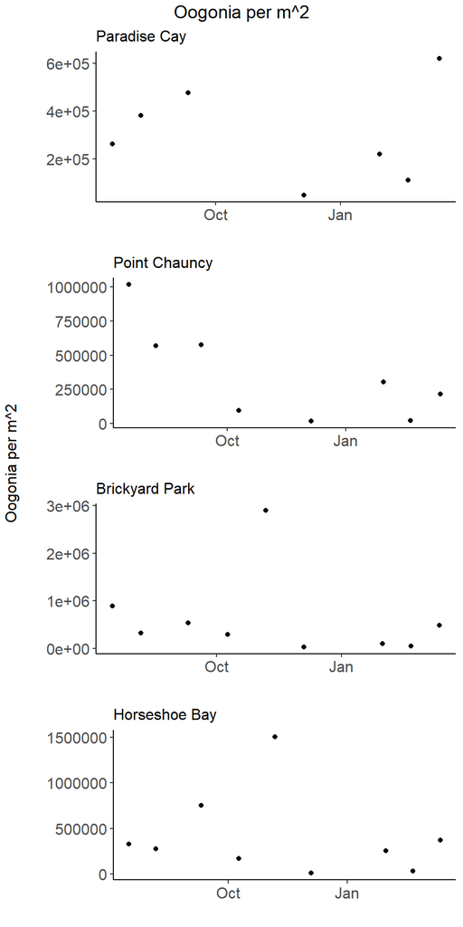

```r
annotate_figure(oopermfigure,
                top = text_grob("Oogonia per m^2", color = "black", face = "plain", size = 14), left = text_grob("Oogonia per m^2", color = "black", rot = 90, size=12))
```

Don’t think this is the best visualization. Also not sure where the month/year went